Métodos de Predictivos (Clasificación o Aprendizaje-Supervisado)

# Índices de Calidad del Modelo y Funciones Auxiliares

**Se necesita cargar las siguientes librerías**

```r
library(tidyverse)
library(glue)
library(scales)
```

**Muestra la distribución de la variable a predecir**

```r
equilibrio.variable.predecir<-function(datos,variable.predecir,ylab="Cantidad de individuos",xlab = "",
                                       main=paste("Distribución de la variable",variable.predecir),
                                       col = NA) {
  gg_color <- function (n) {
     hues <- seq(15, 375, length = n + 1)
     hcl(h = hues, l = 65, c = 100)[1:n]
  }
  if(missing(variable.predecir) | !(variable.predecir %in% colnames(datos))){
    stop("variable.predecir tiene que ser ingresada y ser un nombre de columna", call. = FALSE )
  }
  if(is.character(datos[,variable.predecir]) | is.factor(datos[,variable.predecir])){
    if(length(col) == 0 || is.na(col)){
      col <- gg_color(length(unique(datos[,variable.predecir])))
    }else{
      col <- rep(col,length(unique(datos[,variable.predecir])))
    }
    ggplot(data = datos, mapping = aes_string(x = variable.predecir, fill = variable.predecir)) +
      geom_bar() +
      scale_fill_manual(values = col, name = variable.predecir) +
      labs(x = xlab, y = ylab, title = main) +
      theme_minimal() +
      theme(legend.position = "bottom")
  }else{
    stop("La variable a predecir tienen que ser de tipo factor o character", call. = FALSE )
  }
}
```

**Muestra la distribución de una variable numérica según la variable a predecir**

```r
poder.predictivo.numerica<-function(datos,variable.predecir,variable.comparar,ylab="",xlab="",
                                    main=paste("Densidad de la variable",variable.comparar,'según',variable.predecir),
                                    col=NA){
  gg_color <- function (n) {
     hues <- seq(15, 375, length = n + 1)
     hcl(h = hues, l = 65, c = 100)[1:n]
  }
  if(missing(variable.predecir) | !(variable.predecir %in% colnames(datos))){
    stop("variable.predecir tiene que ser ingresada y ser un nombre de columna", call. = FALSE )
  }
  if(missing(variable.comparar) | !(variable.comparar %in% colnames(datos)) | !is.numeric(datos[,variable.comparar])){
    stop("variable.comparar tiene que ser ingresada y ser un nombre de columna numérica", call. = FALSE )
  }

  if(is.character(datos[,variable.predecir]) | is.factor(datos[,variable.predecir])){
    if(length(col) == 0 || is.na(col)){
      col <- gg_color(length(unique(datos[,variable.predecir])))
    }else{
      col <- rep(col,length(unique(datos[,variable.predecir])))
    }

    ggplot(data = datos, aes_string(variable.comparar, fill = variable.predecir)) +
      geom_density(alpha = .7, color = NA) +
      scale_fill_manual(values = col) +
      labs(title = main , y = ylab, x = xlab ,fill = variable.predecir) +
      theme_minimal() +
      theme(legend.position = 'bottom',
            legend.title = element_blank(),
            text = element_text(size = 15))

  }else{
    stop("La variable a predecir tienen que ser de tipo factor o character", call. = FALSE )
  }
}
```

**Muestra la distribución de una variable categórica según la variable a predecir**

```r
poder.predictivo.categorica<-function(datos,variable.predecir,variable.comparar,ylab="",xlab="",
                                      main=paste("Densidad de la variable",variable.comparar,'según',variable.predecir),
                                      col=NA){
  gg_color <- function (n) {
     hues <- seq(15, 375, length = n + 1)
     hcl(h = hues, l = 65, c = 100)[1:n]
  }
  if(missing(variable.predecir) | !(variable.predecir %in% colnames(datos))){
    stop("variable.predecir tiene que ser ingresada y ser un nombre de columna", call. = FALSE )
  }
  if(missing(variable.comparar) | !(variable.comparar %in% colnames(datos)) |
     !(is.factor(datos[,variable.comparar]) | is.character(datos[,variable.comparar])) ){
    stop("variable.comparar tiene que ser ingresada y ser un nombre de columna categórica", call. = FALSE )
  }

  if(is.character(datos[,variable.predecir]) | is.factor(datos[,variable.predecir])){
    if(length(col) == 0 || is.na(col)){
      col <- gg_color(length(unique(datos[,variable.predecir])))
    }else{
      col <- rep(col,length(unique(datos[,variable.predecir])))
    }

    datos2 <- datos %>%
      dplyr::group_by_(variable.comparar, variable.predecir) %>%
      dplyr::summarise(count = n())

    if(variable.comparar != variable.predecir){
      datos2 <-   datos2 %>% dplyr::group_by_(variable.comparar)
    }
    datos2 <- datos2 %>% dplyr::mutate(prop = round(count/sum(count),4))

    ggplot(data = datos2, mapping = aes_string(x = variable.comparar, y = "prop", fill = variable.predecir)) +
      geom_col(position = "fill") +
      geom_text(aes(label = glue("{percent(prop)} ({count})")), position = position_stack(vjust = .5), color = "white") +
      scale_y_continuous(label = percent) +
      labs(y =  xlab, x  = ylab, title = main) +
      scale_fill_manual(values = col, name = variable.predecir) +
      theme(legend.position = "bottom")+
      coord_flip()

  }else{
    stop("La variable a predecir tienen que ser de tipo factor o character", call. = FALSE )
  }
}
```

**Índices para matrices NxN**

```r
indices.general <- function(MC) {
  precision.global <- sum(diag(MC))/sum(MC)
  error.global <- 1 - precision.global
  precision.categoria <- diag(MC)/rowSums(MC)
  res <- list(matriz.confusion = MC, precision.global = precision.global, error.global = error.global,
              precision.categoria = precision.categoria)
  names(res) <- c("Matriz de Confusión", "Precisión Global", "Error Global",
                  "Precisión por categoría")
  return(res)
}
```

# El método de Potenciación - ADA Boosting

Es importante saber que este método funciona sólo cuando la variable a predecir tiene solo para 2 categorías.

## Ejemplo Scoring

```r
setwd("~/Datos(CSV)/")
datos<-read.csv("MuestraCredito5000V2.csv",sep = ";",header=T)

# Recodifica las variables como categóricas ordinales
datos$IngresoNeto <- factor(datos$IngresoNeto, ordered = TRUE)
datos$CoefCreditoAvaluo <- factor(datos$CoefCreditoAvaluo, ordered = TRUE)
```

```r
datos
```

| MontoCredito | IngresoNeto | CoefCreditoAvaluo | MontoCuota | GradoAcademico | BuenPagador |
| --- | --- | --- | --- | --- | --- |
| 14327 | 1 | 1 | MuyBajo | Bachiller | Si |
| 111404 | 1 | 1 | MuyBajo | Bachiller | Si |
| 21128 | 1 | 1 | MuyBajo | Bachiller | Si |
| 15426 | 2 | 1 | MuyBajo | Bachiller | Si |
| 10351 | 1 | 1 | MuyBajo | Bachiller | Si |
| 27060 | 1 | 1 | MuyBajo | Bachiller | Si |
| 243369 | 1 | 1 | MuyBajo | Bachiller | Si |
| 16300 | 2 | 1 | MuyBajo | Bachiller | Si |
| 18319 | 2 | 1 | MuyBajo | Bachiller | Si |
| 107037 | 2 | 1 | MuyBajo | Bachiller | Si |

[output cut: 4990 more lines]

```r
str(datos)
```

```
'data.frame':   5000 obs. of  6 variables:
 $ MontoCredito     : int  14327 111404 21128 15426 10351 27060 243369 16300 18319 107037 ...
 $ IngresoNeto      : Ord.factor w/ 2 levels "1"<"2": 1 1 1 2 1 1 1 2 2 2 ...
 $ CoefCreditoAvaluo: Ord.factor w/ 12 levels "1"<"2"<"3"<"4"<..: 1 1 1 1 1 1 1 1 1 1 ...
 $ MontoCuota       : Factor w/ 4 levels "Alto","Bajo",..: 4 4 4 4 4 4 4 4 4 4 ...
 $ GradoAcademico   : Factor w/ 2 levels "Bachiller","Licenciatura": 1 1 1 1 1 1 1 1 1 1 ...
 $ BuenPagador      : Factor w/ 2 levels "No","Si": 2 2 2 2 2 2 2 2 2 2 ...
```

### Distribución de las categorías

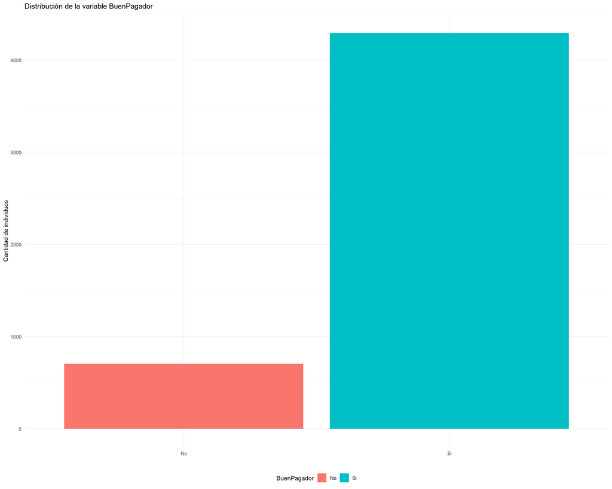

```r
equilibrio.variable.predecir(datos,"BuenPagador")
```

### Predicción

Vamos a generar al azar una tabla de testing con 15% de los datos y una tabla de aprendizaje con 85%

```r
muestra <- sample(1:nrow(datos), floor(nrow(datos)*0.15))
ttesting <- datos[muestra,]
taprendizaje <- datos[-muestra,]
```

### Paquete ada

**Se cargan las librerías**

```r
library(ada)
```

**Se genera el modelo**

```r
# Genera el modelo con parámetros por defecto
modelo <- ada(BuenPagador~., data = taprendizaje)
modelo
```

```
Call:
ada(BuenPagador ~ ., data = taprendizaje)

Loss: exponential Method: discrete   Iteration: 50

Final Confusion Matrix for Data:
          Final Prediction
True value   No   Si
        No  429  166
        Si   42 3613

Train Error: 0.049

Out-Of-Bag Error:  0.05  iteration= 50

Additional Estimates of number of iterations:

train.err1 train.kap1
        14         48
```

**Se genera la predicción**

```r
prediccion <- predict(modelo, ttesting[,-6])
prediccion
```

```
  [1] Si No Si Si Si Si No Si Si Si Si Si No Si Si Si Si Si Si Si Si Si Si
 [24] Si No Si Si Si Si Si Si Si Si Si Si Si Si Si Si Si Si Si Si No Si Si
 [47] Si No Si Si Si Si Si Si Si Si Si Si No No No Si Si Si Si Si Si Si Si
 [70] Si Si Si Si Si Si No Si Si Si Si Si Si Si Si Si Si Si Si Si Si Si Si
 [93] No Si Si Si Si Si Si Si Si Si Si Si No Si Si Si Si Si Si Si Si Si Si
[116] Si Si Si Si Si Si Si No No Si Si Si Si Si Si Si No Si Si No Si Si Si
[139] Si Si Si Si Si Si Si Si Si Si Si Si Si No Si Si Si Si Si Si No No Si
[162] Si Si Si No Si Si Si Si Si Si Si Si Si Si No Si Si Si Si Si Si Si Si
[185] Si No Si Si Si No Si Si Si Si Si No Si Si Si Si Si Si Si No Si Si Si
[208] Si Si Si Si Si Si Si Si Si Si Si Si Si Si Si Si Si Si Si Si Si Si Si
[231] Si Si Si Si Si Si Si Si No Si Si Si Si No Si Si Si Si Si Si Si Si Si
[254] Si Si Si Si Si Si Si Si Si Si Si Si Si Si Si Si Si Si Si Si Si Si Si
[277] Si Si No Si Si Si Si Si Si Si Si Si Si Si Si Si Si Si Si Si Si No Si
[300] No Si Si Si Si No Si Si Si Si Si Si Si Si Si Si Si Si Si Si No Si Si
[323] No No Si Si Si Si Si Si Si Si No Si Si Si Si Si Si Si Si Si Si Si Si
```

[output cut: 19 more lines]

**Graficar el modelo**

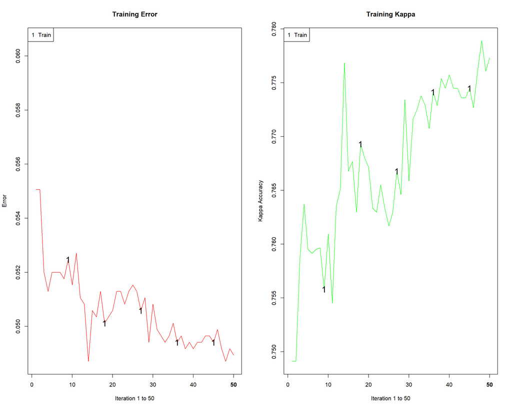

```r
plot(modelo,TRUE,TRUE)
```

**La importancia de variables según el modelo**

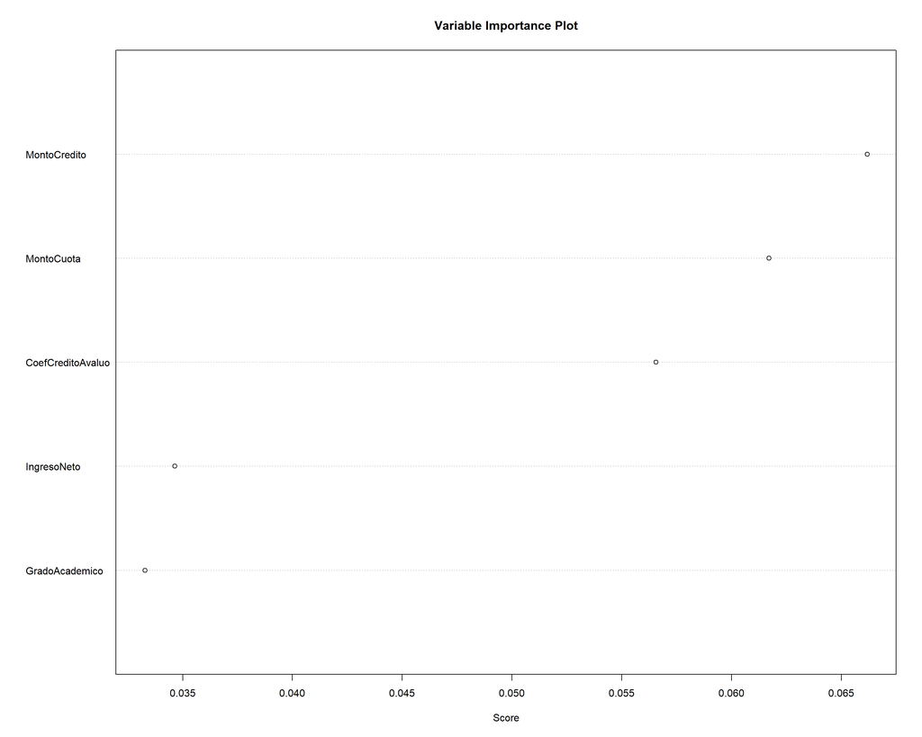

```r
varplot(modelo)
```

**Se genera la matriz de confusión**

```r
MC <- table(ttesting$BuenPagador, prediccion)
MC
```

```
    prediccion
      No  Si
  No  75  35
  Si   8 632
```

**Índices de calidad de la predicción**

```r
indices <- indices.general(MC)
indices
```

```
$`Matriz de Confusión`
    prediccion
      No  Si
  No  75  35
  Si   8 632

$`Precisión Global`
[1] 0.9426667

$`Error Global`
[1] 0.05733333

$`Precisión por categoría`
       No        Si
0.6818182 0.9875000
```

### Paquete trainR

**Se cargan las librerías**

```r
library(trainR)
```

**Se genera el modelo**

```r
modelo <- train.ada(BuenPagador~., data = taprendizaje)
modelo
```

```
Call:
ada(BuenPagador ~ ., data = taprendizaje)

Loss: exponential Method: discrete   Iteration: 50

Final Confusion Matrix for Data:
          Final Prediction
True value   No   Si
        No  421  174
        Si   40 3615

Train Error: 0.05

Out-Of-Bag Error:  0.051  iteration= 43

Additional Estimates of number of iterations:

train.err1 train.kap1
        13         13
```

**Se genera la predicción**

```r
prediccion <- predict(modelo, ttesting)
prediccion
```

```
  [1] Si No Si Si Si Si No Si Si Si Si Si Si Si Si Si Si Si Si Si Si Si Si
 [24] Si No Si Si Si Si Si Si Si Si Si Si Si Si Si Si Si Si Si Si No Si Si
 [47] Si No Si Si Si Si Si Si Si Si Si Si No No No Si Si Si Si Si Si Si Si
 [70] Si Si Si Si Si Si No Si Si Si Si Si Si Si Si Si Si Si Si Si Si Si Si
 [93] No Si Si Si Si Si Si Si Si Si Si Si No Si Si Si Si Si Si Si Si Si Si
[116] Si Si Si Si Si Si Si No No Si Si Si Si Si Si Si No Si Si No Si Si Si
[139] Si Si Si Si Si Si Si Si Si Si Si Si Si No Si Si Si Si Si Si No Si Si
[162] Si Si Si No Si Si No Si Si Si Si Si Si Si No Si Si Si Si Si Si Si Si
[185] Si No Si Si No No Si Si Si Si Si No Si Si Si Si Si Si Si No Si Si Si
[208] Si Si Si Si Si Si Si Si Si Si Si Si Si Si Si Si Si Si Si Si Si Si Si
[231] Si Si Si Si Si Si Si Si No Si Si Si Si No Si Si Si Si Si Si Si Si Si
[254] Si Si Si Si Si Si Si Si Si Si Si Si Si Si Si Si Si Si Si Si Si Si Si
[277] Si Si No Si Si Si Si Si Si Si Si Si Si Si Si Si Si Si Si Si Si No Si
[300] No Si Si Si Si No Si Si Si Si Si Si Si Si Si Si Si Si Si Si No Si Si
[323] No Si Si Si Si Si Si Si Si Si No Si Si Si Si Si Si Si Si Si Si Si Si
```

[output cut: 19 more lines]

**Graficar el modelo**

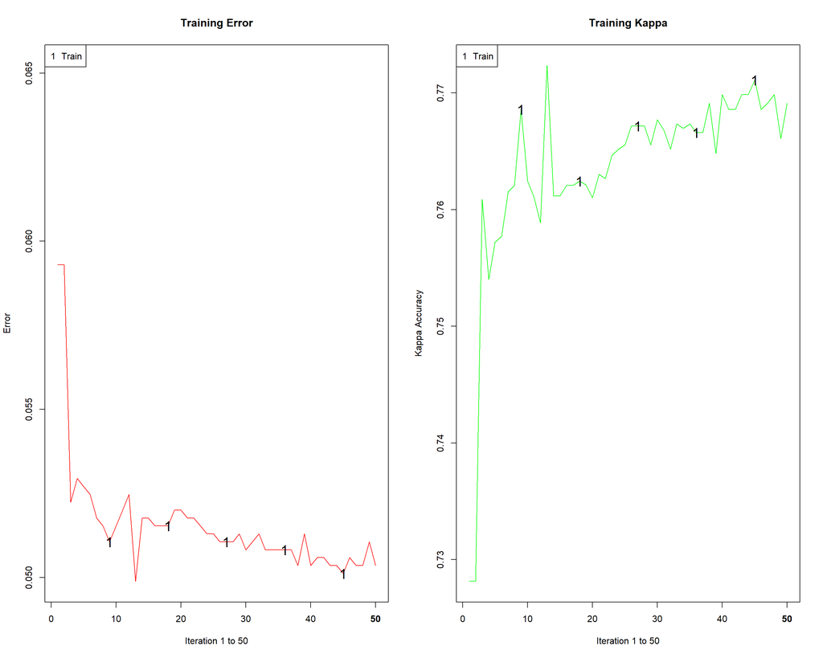

```r
plot(modelo,TRUE,TRUE)
```

**La importancia de variables según el modelo**

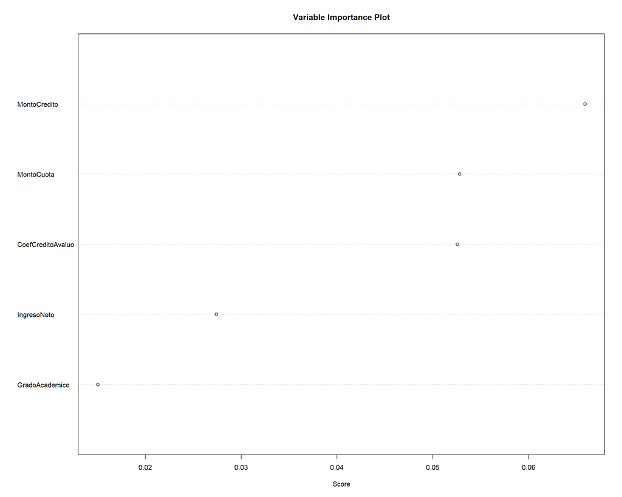

```r
varplot(modelo)
```

**Se genera la matriz de confusión**

```r
MC <- confusion.matrix(ttesting, prediccion)
MC
```

```
    prediction
real  No  Si
  No  73  37
  Si   8 632
```

**Índices de calidad de la predicción**

```r
indices <- general.indexes(mc = MC)
indices
```

```
Confusion Matrix:
    prediction
real  No  Si
  No  73  37
  Si   8 632

Overall Accuracy: 0.9400
Overall Error:    0.0600

Category Accuracy:

           No           Si
     0.663636     0.987500
```

**Podemos omitir crear la matriz de confusión**

```r
indices <- general.indexes(ttesting, prediccion)
indices
```

```
Confusion Matrix:
    prediction
real  No  Si
  No  73  37
  Si   8 632

Overall Accuracy: 0.9400
Overall Error:    0.0600

Category Accuracy:

           No           Si
     0.663636     0.987500
```

### Paquete ada

**Se cargan las librerías**

```r
library(ada)
```

**Se genera el modelo**

```r
modelo <- ada(BuenPagador~., data = taprendizaje, iter = 200, type = 'real',
              control = rpart.control(minsplit = 2, maxdepth = 30))
modelo
```

```
Call:
ada(BuenPagador ~ ., data = taprendizaje, iter = 200, type = "real",
    control = rpart.control(minsplit = 2, maxdepth = 30))

Loss: exponential Method: real   Iteration: 200

Final Confusion Matrix for Data:
          Final Prediction
True value   No   Si
        No  447  148
        Si   40 3615

Train Error: 0.044

Out-Of-Bag Error:  0.046  iteration= 186

Additional Estimates of number of iterations:

train.err1 train.kap1
       195        195
```

**Se genera la predicción**

```r
prediccion <- predict(modelo, ttesting[,-6])
prediccion
```

```
  [1] Si No Si Si Si Si No Si Si Si Si Si No Si Si Si Si Si Si Si Si Si Si
 [24] Si No Si Si Si Si Si Si Si Si Si Si Si Si Si Si Si Si Si Si No Si Si
 [47] Si No Si Si Si Si Si Si Si Si Si Si No No No Si Si Si Si Si Si Si Si
 [70] Si Si Si Si Si Si No Si Si Si Si Si Si Si Si Si Si Si Si Si Si Si Si
 [93] No Si Si Si Si Si Si Si Si Si Si Si No Si Si Si Si Si Si Si No Si Si
[116] Si Si Si Si Si Si Si No No Si Si Si Si Si Si Si No Si Si No Si Si Si
[139] Si Si Si Si Si Si Si Si Si Si Si Si Si No Si Si Si Si Si Si No No Si
[162] Si Si Si No Si Si No Si Si Si Si Si Si Si No Si Si Si Si Si Si Si Si
[185] Si No Si Si No No No Si Si Si Si No Si Si Si Si Si Si Si No Si Si Si
[208] Si Si Si Si Si Si Si Si Si Si Si Si Si Si Si Si Si No Si Si Si Si Si
[231] Si Si Si Si Si Si Si Si No Si Si Si Si No Si Si Si Si Si Si Si Si Si
[254] Si Si Si No Si Si Si Si Si Si Si No Si Si Si Si Si Si Si Si Si Si Si
[277] Si Si No Si Si Si Si Si Si Si Si Si Si Si Si Si Si Si Si Si Si No Si
[300] No Si Si Si Si No Si Si Si Si Si Si Si Si Si Si Si Si Si Si No Si Si
[323] No Si Si Si Si Si Si Si Si Si No Si Si Si Si Si Si Si Si Si Si Si Si
```

[output cut: 19 more lines]

**Graficar el modelo**

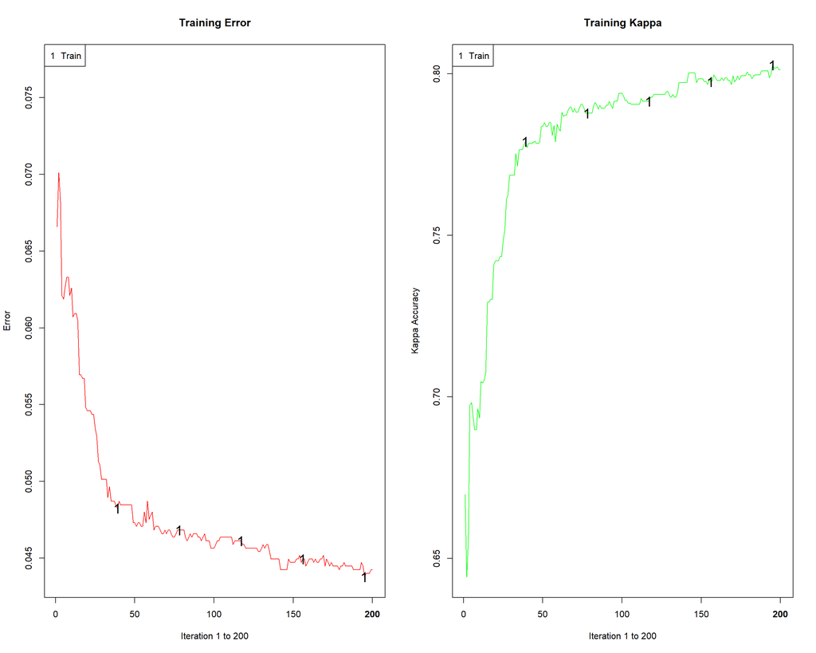

```r
plot(modelo,TRUE,TRUE)
```

**La importancia de variables según el modelo**

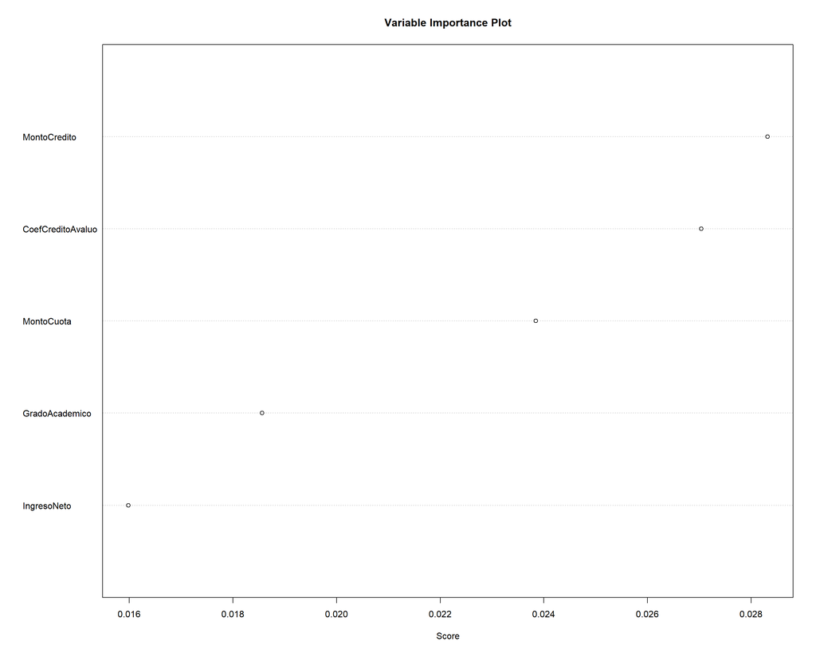

```r
varplot(modelo)
```

**Se genera la matriz de confusión**

```r
MC <- table(ttesting$BuenPagador, prediccion)
MC
```

```
    prediccion
      No  Si
  No  79  31
  Si  10 630
```

**Índices de calidad de la predicción**

```r
indices <- indices.general(MC)
indices
```

```
$`Matriz de Confusión`
    prediccion
      No  Si
  No  79  31
  Si  10 630

$`Precisión Global`
[1] 0.9453333

$`Error Global`
[1] 0.05466667

$`Precisión por categoría`
       No        Si
0.7181818 0.9843750
```

### Paquete trainR

**Se cargan las librerías**

```r
library(trainR)
```

**Se genera el modelo**

```r
modelo <- train.ada(BuenPagador~., data = taprendizaje, iter = 200, type = 'real',
                    control = rpart.control(minsplit = 2, maxdepth = 30))
modelo
```

```
Call:
ada(BuenPagador ~ ., data = taprendizaje, iter = 200, type = "real",
    control = rpart.control(minsplit = 2, maxdepth = 30))

Loss: exponential Method: real   Iteration: 200

Final Confusion Matrix for Data:
          Final Prediction
True value   No   Si
        No  440  155
        Si   39 3616

Train Error: 0.046

Out-Of-Bag Error:  0.046  iteration= 165

Additional Estimates of number of iterations:

train.err1 train.kap1
       163        163
```

**Se genera la predicción**

```r
prediccion <- predict(modelo, ttesting)
prediccion
```

```
  [1] Si No Si Si Si Si No Si Si Si Si Si No Si Si Si Si Si Si Si Si Si Si
 [24] Si No Si Si Si Si Si Si Si Si Si Si Si Si Si Si Si Si Si Si No Si Si
 [47] Si No Si Si Si Si Si Si Si Si Si Si No No No Si Si Si Si Si Si Si Si
 [70] Si Si Si Si Si Si No Si Si Si Si Si Si Si Si Si Si Si Si Si Si Si Si
 [93] No Si Si Si Si Si Si Si Si Si Si Si No Si Si Si Si Si Si Si Si Si Si
[116] Si Si Si Si Si Si Si No No Si Si Si Si Si Si Si No Si Si No Si Si Si
[139] Si Si Si Si Si Si Si Si Si Si Si Si Si No Si Si Si Si Si Si No No Si
[162] Si Si Si No Si Si No Si Si Si Si Si Si Si No Si Si Si Si Si Si Si Si
[185] Si No Si Si Si No No Si Si Si Si No Si Si Si Si Si Si Si No Si Si Si
[208] Si Si Si Si Si Si Si Si Si Si Si Si Si Si Si Si Si Si Si Si Si Si Si
[231] Si Si Si Si Si Si Si Si No Si Si Si Si No Si Si Si Si Si Si Si Si Si
[254] Si Si Si No Si Si Si Si Si Si Si Si Si Si Si Si Si Si Si Si Si Si Si
[277] Si Si No Si Si Si Si Si Si Si Si Si Si Si Si Si Si Si Si Si Si No Si
[300] No Si Si Si Si No Si Si Si Si Si Si Si Si Si Si Si Si Si Si No Si Si
[323] No Si Si Si Si Si Si Si Si Si No Si Si Si Si Si Si Si Si Si Si Si Si
```

[output cut: 19 more lines]

**Graficar el modelo**

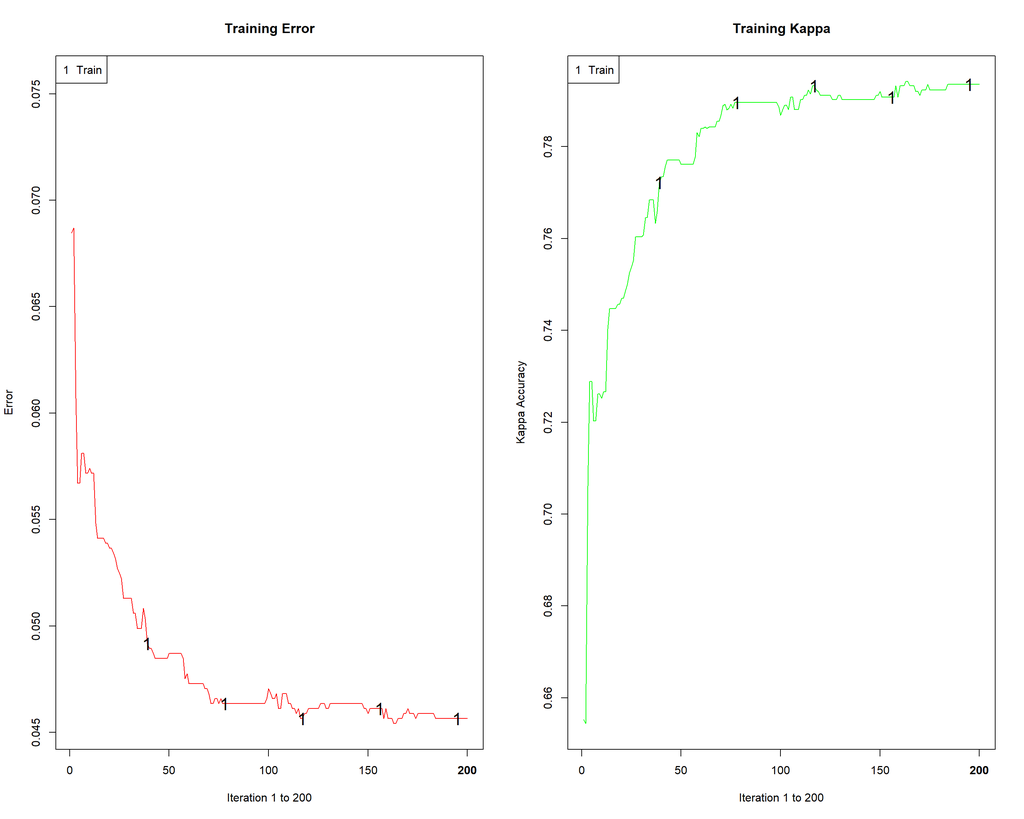

```r
plot(modelo,TRUE,TRUE)
```

**La importancia de variables según el modelo**

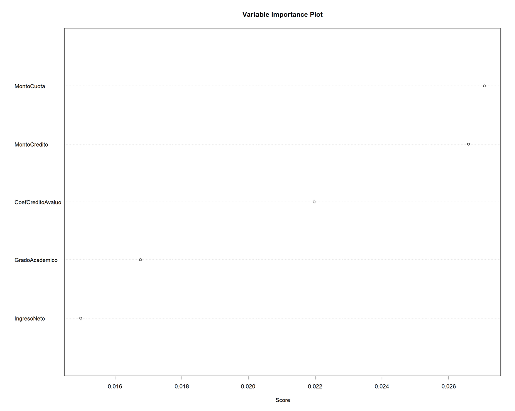

```r
varplot(modelo)
```

**Se genera la matriz de confusión**

```r
MC <- confusion.matrix(ttesting, prediccion)
MC
```

```
    prediction
real  No  Si
  No  78  32
  Si   6 634
```

**Índices de calidad de la predicción**

```r
indices <- general.indexes(mc = MC)
indices
```

```
Confusion Matrix:
    prediction
real  No  Si
  No  78  32
  Si   6 634

Overall Accuracy: 0.9493
Overall Error:    0.0507

Category Accuracy:

           No           Si
     0.709091     0.990625
```

**Podemos omitir crear la matriz de confusión**

```r
indices <- general.indexes(ttesting, prediccion)
indices
```

```
Confusion Matrix:
    prediction
real  No  Si
  No  78  32
  Si   6 634

Overall Accuracy: 0.9493
Overall Error:    0.0507

Category Accuracy:

           No           Si
     0.709091     0.990625
```

### Selección de Variables

Utilizando los datos que previamente cargamos

```r
datos
```

| MontoCredito | IngresoNeto | CoefCreditoAvaluo | MontoCuota | GradoAcademico | BuenPagador |
| --- | --- | --- | --- | --- | --- |
| 14327 | 1 | 1 | MuyBajo | Bachiller | Si |
| 111404 | 1 | 1 | MuyBajo | Bachiller | Si |
| 21128 | 1 | 1 | MuyBajo | Bachiller | Si |
| 15426 | 2 | 1 | MuyBajo | Bachiller | Si |
| 10351 | 1 | 1 | MuyBajo | Bachiller | Si |
| 27060 | 1 | 1 | MuyBajo | Bachiller | Si |
| 243369 | 1 | 1 | MuyBajo | Bachiller | Si |
| 16300 | 2 | 1 | MuyBajo | Bachiller | Si |
| 18319 | 2 | 1 | MuyBajo | Bachiller | Si |
| 107037 | 2 | 1 | MuyBajo | Bachiller | Si |

[output cut: 4990 more lines]

Podemos visualizar la distribución de las variables numéricas y categóricas según la variable a predecir.

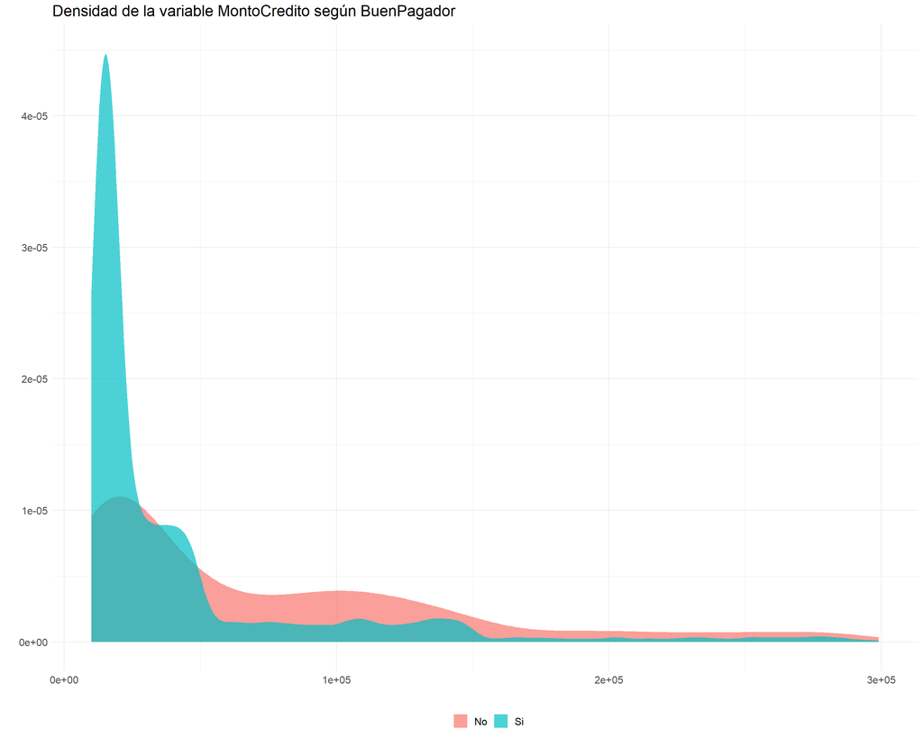

```r
poder.predictivo.numerica(datos, "BuenPagador","MontoCredito")
```

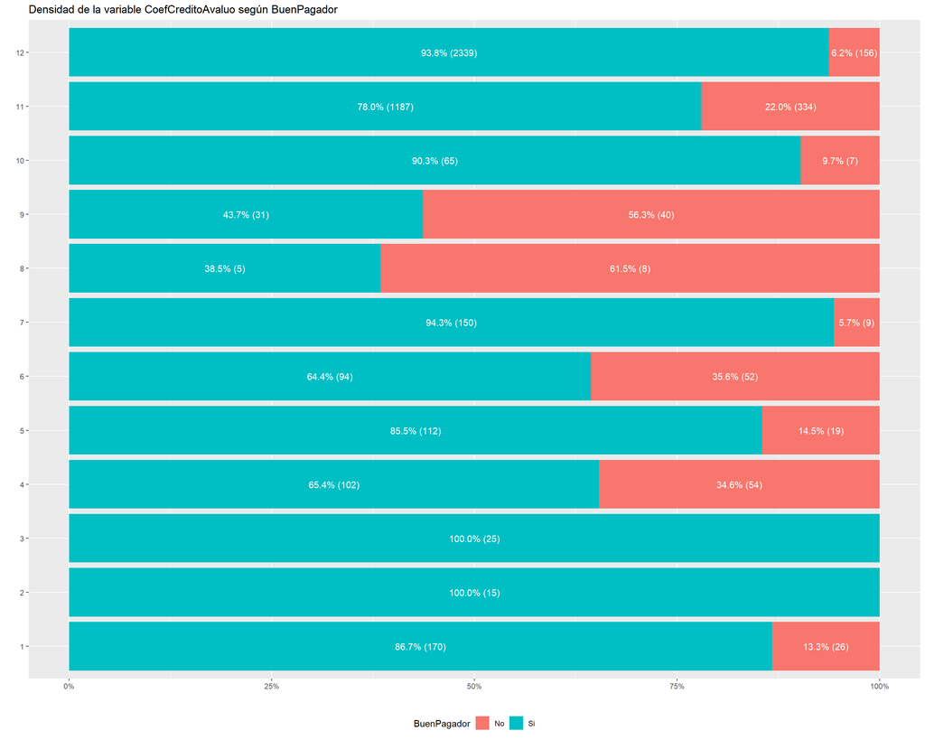

```r
poder.predictivo.categorica(datos,"BuenPagador", "CoefCreditoAvaluo")
```

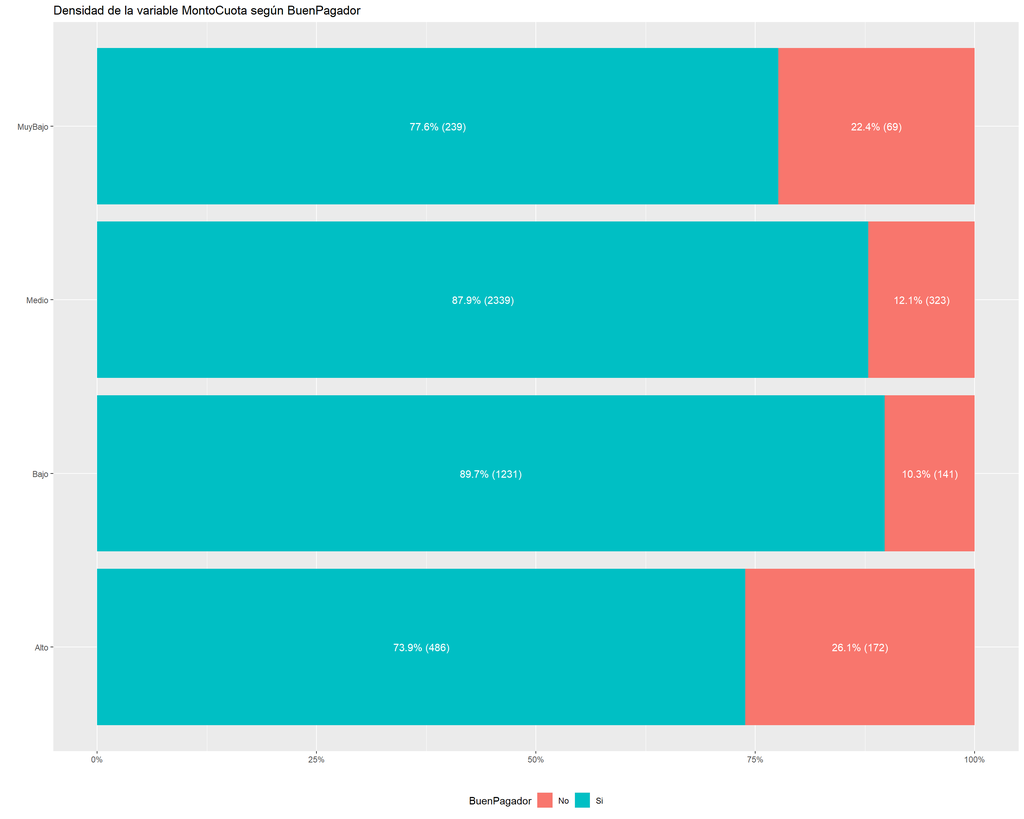

```r
poder.predictivo.categorica(datos,"BuenPagador", "MontoCuota")
```

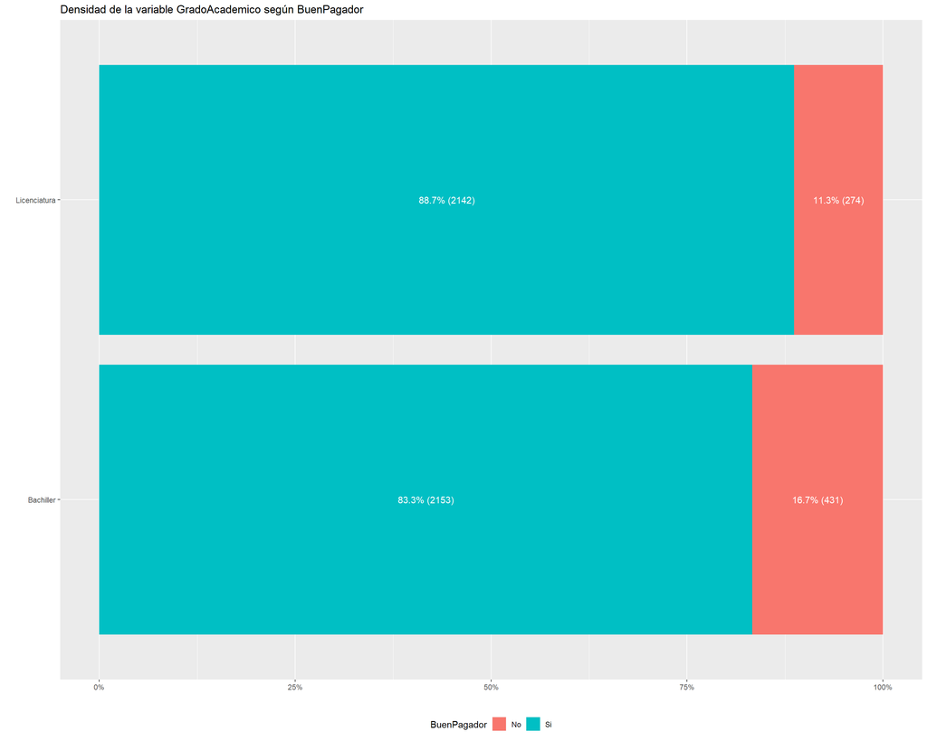

```r
poder.predictivo.categorica(datos,"BuenPagador", "GradoAcademico")
```

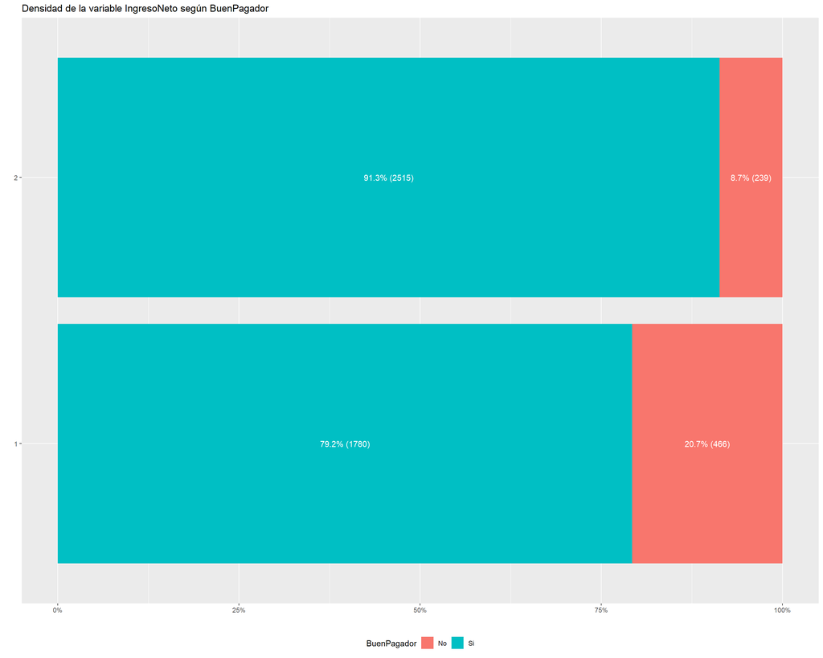

```r
poder.predictivo.categorica(datos,"BuenPagador", "IngresoNeto")
```

### Predicción con selección de variables.

Utilizando los mismo datos para prueba (`ttesting`) y aprendizaje (`taprendizaje`) que creamos anteriormente.

```r
ttesting
```

|  | MontoCredito | IngresoNeto | CoefCreditoAvaluo | MontoCuota | GradoAcademico | BuenPagador |
| --- | --- | --- | --- | --- | --- | --- |
| 2973 | 44872 | 1 | 12 | Bajo | Bachiller | Si |
| 2318 | 30862 | 2 | 11 | Medio | Bachiller | No |
| 641 | 192308 | 2 | 12 | Bajo | Bachiller | Si |
| 1627 | 19474 | 2 | 12 | Medio | Bachiller | Si |
| 602 | 10278 | 2 | 12 | Bajo | Bachiller | Si |
| 1209 | 28162 | 2 | 7 | Medio | Licenciatura | Si |
| 2203 | 115666 | 2 | 4 | Bajo | Bachiller | No |
| 3426 | 13635 | 2 | 11 | Medio | Licenciatura | Si |
| 4415 | 14154 | 2 | 11 | Alto | Licenciatura | Si |
| 1531 | 17315 | 1 | 11 | Medio | Licenciatura | Si |

[output cut: 740 more lines]

```r
taprendizaje
```

|  | MontoCredito | IngresoNeto | CoefCreditoAvaluo | MontoCuota | GradoAcademico | BuenPagador |
| --- | --- | --- | --- | --- | --- | --- |
| 1 | 14327 | 1 | 1 | MuyBajo | Bachiller | Si |
| 2 | 111404 | 1 | 1 | MuyBajo | Bachiller | Si |
| 3 | 21128 | 1 | 1 | MuyBajo | Bachiller | Si |
| 4 | 15426 | 2 | 1 | MuyBajo | Bachiller | Si |
| 5 | 10351 | 1 | 1 | MuyBajo | Bachiller | Si |
| 6 | 27060 | 1 | 1 | MuyBajo | Bachiller | Si |
| 7 | 243369 | 1 | 1 | MuyBajo | Bachiller | Si |
| 8 | 16300 | 2 | 1 | MuyBajo | Bachiller | Si |
| 9 | 18319 | 2 | 1 | MuyBajo | Bachiller | Si |
| 10 | 107037 | 2 | 1 | MuyBajo | Bachiller | Si |

[output cut: 4240 more lines]

### Paquete ada

**Se cargan las librerías**

```r
library(ada)
```

**Se genera el modelo**

```r
modelo <- ada(BuenPagador~CoefCreditoAvaluo+MontoCredito+IngresoNeto,
              data = taprendizaje, iter = 200, type = 'real',
              control = rpart.control(minsplit = 2, maxdepth = 30))
modelo
```

```
Call:
ada(BuenPagador ~ CoefCreditoAvaluo + MontoCredito + IngresoNeto,
    data = taprendizaje, iter = 200, type = "real", control = rpart.control(minsplit = 2,
        maxdepth = 30))

Loss: exponential Method: real   Iteration: 200

Final Confusion Matrix for Data:
          Final Prediction
True value   No   Si
        No  134  461
        Si   70 3585

Train Error: 0.125

Out-Of-Bag Error:  0.124  iteration= 77

Additional Estimates of number of iterations:

train.err1 train.kap1
        93        200
```

**Se genera la predicción**

```r
prediccion <- predict(modelo, ttesting[,-6])
prediccion
```

```
  [1] Si Si Si Si Si Si Si Si Si Si Si Si No Si Si Si No Si Si Si Si Si Si
 [24] Si No Si Si Si Si Si Si Si Si Si Si Si Si Si Si Si Si Si Si Si Si Si
 [47] Si No Si Si Si Si Si Si Si Si Si Si No No Si Si Si Si Si Si Si Si Si
 [70] Si Si Si Si Si Si Si Si Si Si Si Si Si Si Si Si Si Si Si Si Si Si Si
 [93] No Si Si Si Si Si Si Si Si Si Si Si Si Si Si Si Si Si Si Si No Si Si
[116] Si Si Si Si Si Si Si Si No Si Si Si Si Si Si Si Si Si Si No Si Si Si
[139] Si Si Si Si Si Si Si Si Si Si Si Si Si No Si Si Si Si Si Si Si No Si
[162] Si Si Si No Si Si No Si No Si Si Si Si Si Si Si Si Si Si Si Si Si Si
[185] Si Si Si Si Si Si No Si Si Si Si Si Si Si Si No Si Si Si No Si Si Si
[208] Si Si Si Si Si Si Si Si Si Si Si Si Si Si Si Si Si Si Si Si Si Si Si
[231] Si Si Si Si Si Si Si Si Si Si Si Si Si Si Si Si Si Si Si Si Si Si Si
[254] Si Si Si Si Si Si Si Si Si Si Si Si Si Si Si Si Si Si Si Si Si Si Si
[277] Si Si No Si Si Si Si Si Si Si Si Si Si Si Si Si Si Si Si Si Si Si Si
[300] Si Si Si Si Si No Si Si Si Si Si No Si Si Si Si Si Si Si No No Si Si
[323] Si Si Si Si Si Si Si Si Si Si No Si Si Si Si Si Si Si Si Si Si Si Si
```

[output cut: 19 more lines]

**Graficar el modelo**

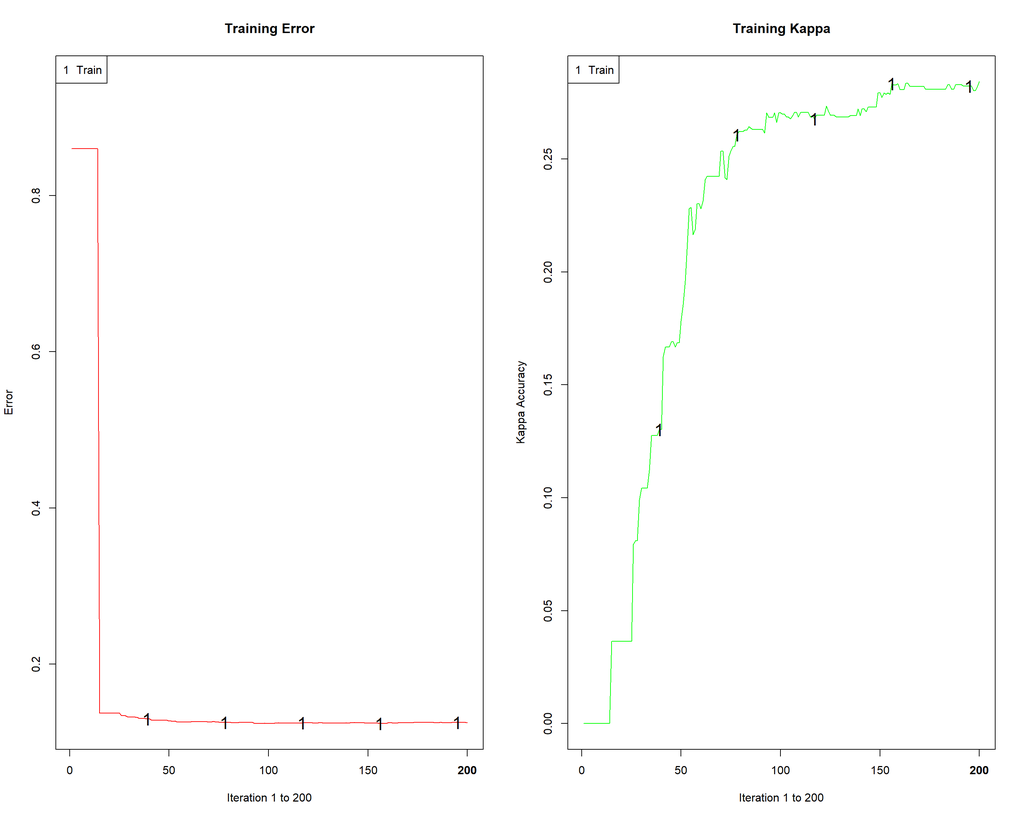

```r
plot(modelo,TRUE,TRUE)
```

**La importancia de variables según el modelo**

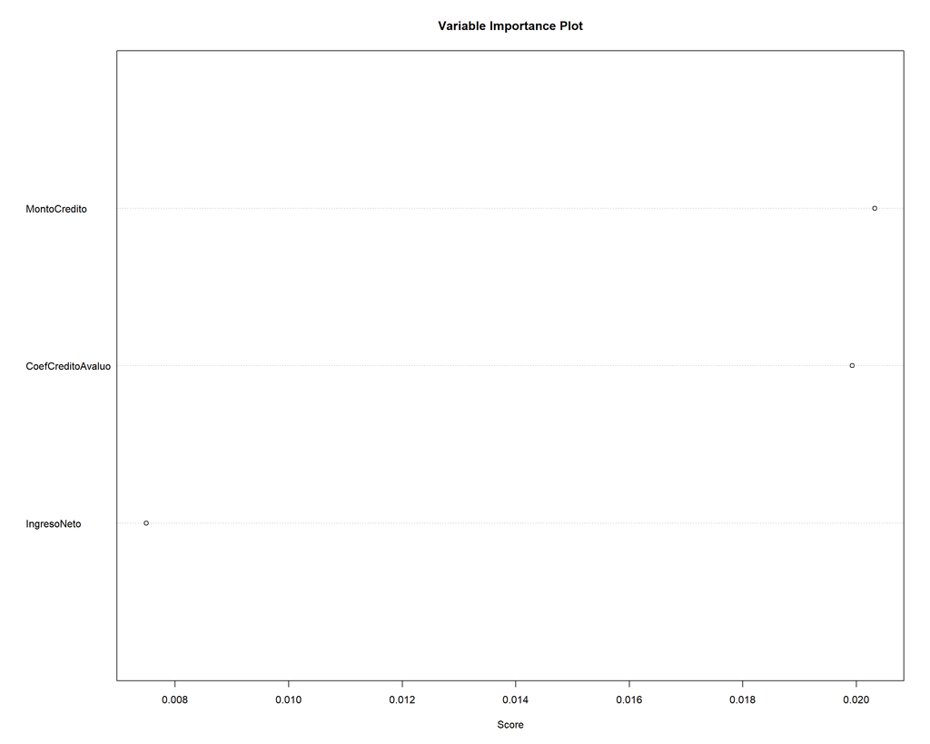

```r
varplot(modelo)
```

**Se genera la matriz de confusión**

```r
MC <- table(ttesting$BuenPagador, prediccion)
MC
```

```
    prediccion
      No  Si
  No  23  87
  Si  16 624
```

**Índices de calidad de la predicción**

```r
indices <- indices.general(MC)
indices
```

```
$`Matriz de Confusión`
    prediccion
      No  Si
  No  23  87
  Si  16 624

$`Precisión Global`
[1] 0.8626667

$`Error Global`
[1] 0.1373333

$`Precisión por categoría`
       No        Si
0.2090909 0.9750000
```

### Paquete trainR

**Se cargan las librerías**

```r
library(trainR)
```

**Se genera el modelo**

```r
modelo <- train.ada(BuenPagador~CoefCreditoAvaluo+MontoCredito+IngresoNeto,
                    data = taprendizaje, iter = 200, type = 'real',
                    control = rpart.control(minsplit = 2, maxdepth = 30))
modelo
```

```
Call:
ada(BuenPagador ~ CoefCreditoAvaluo + MontoCredito + IngresoNeto,
    data = taprendizaje, iter = 200, type = "real", control = rpart.control(minsplit = 2,
        maxdepth = 30))

Loss: exponential Method: real   Iteration: 200

Final Confusion Matrix for Data:
          Final Prediction
True value   No   Si
        No  127  468
        Si   56 3599

Train Error: 0.123

Out-Of-Bag Error:  0.124  iteration= 82

Additional Estimates of number of iterations:

train.err1 train.kap1
       152        189
```

**Se genera la predicción**

```r
prediccion <- predict(modelo, ttesting)
prediccion
```

```
  [1] Si Si Si Si Si Si Si Si Si Si Si Si No Si Si Si No Si Si Si Si Si Si
 [24] Si No Si Si Si Si Si Si Si Si Si Si Si Si Si Si Si Si Si Si Si Si Si
 [47] Si No Si Si Si Si Si Si Si Si Si Si No No Si Si Si Si Si Si Si Si Si
 [70] Si Si Si Si Si Si Si Si Si Si Si Si Si Si Si Si Si Si Si Si Si Si Si
 [93] No Si Si Si Si Si Si Si Si Si Si Si Si Si Si Si Si Si Si Si No Si Si
[116] Si Si Si Si Si Si Si Si No Si Si Si Si Si Si Si Si Si Si No Si Si Si
[139] Si Si Si Si Si Si Si Si Si Si Si Si Si No Si Si Si Si Si Si Si No Si
[162] Si Si Si No Si Si No Si Si Si Si Si Si Si Si Si Si Si Si Si Si Si Si
[185] Si Si Si Si Si No No Si Si Si Si Si Si Si Si No Si Si Si Si Si Si Si
[208] Si Si Si Si Si Si Si Si Si Si Si Si Si Si Si Si Si Si Si Si Si Si Si
[231] Si Si Si Si Si Si Si Si Si Si Si Si Si Si Si Si Si Si Si Si Si Si Si
[254] Si Si Si Si Si Si Si Si Si Si Si Si Si Si Si Si Si Si Si Si Si Si Si
[277] Si Si No Si Si Si Si Si Si Si Si Si Si Si Si Si Si Si Si Si Si Si Si
[300] Si Si Si Si Si No Si Si Si Si Si No Si Si Si Si Si Si Si No No Si Si
[323] Si Si Si Si Si Si Si Si Si Si No Si Si Si Si Si Si Si Si Si Si Si Si
```

[output cut: 19 more lines]

**Graficar el modelo**

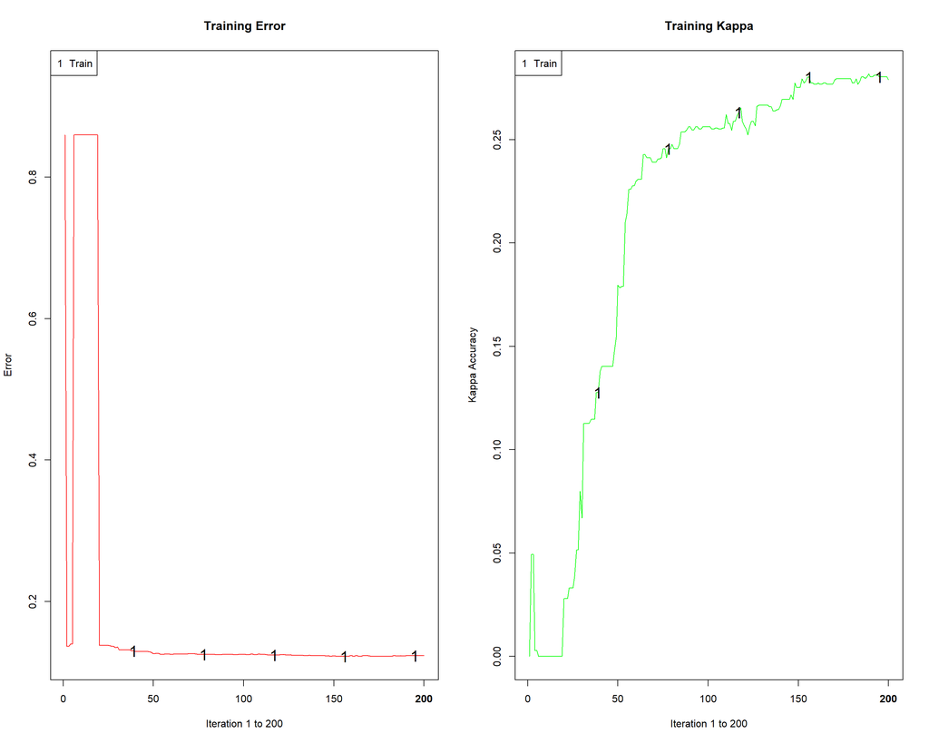

```r
plot(modelo,TRUE,TRUE)
```

**La importancia de variables según el modelo**

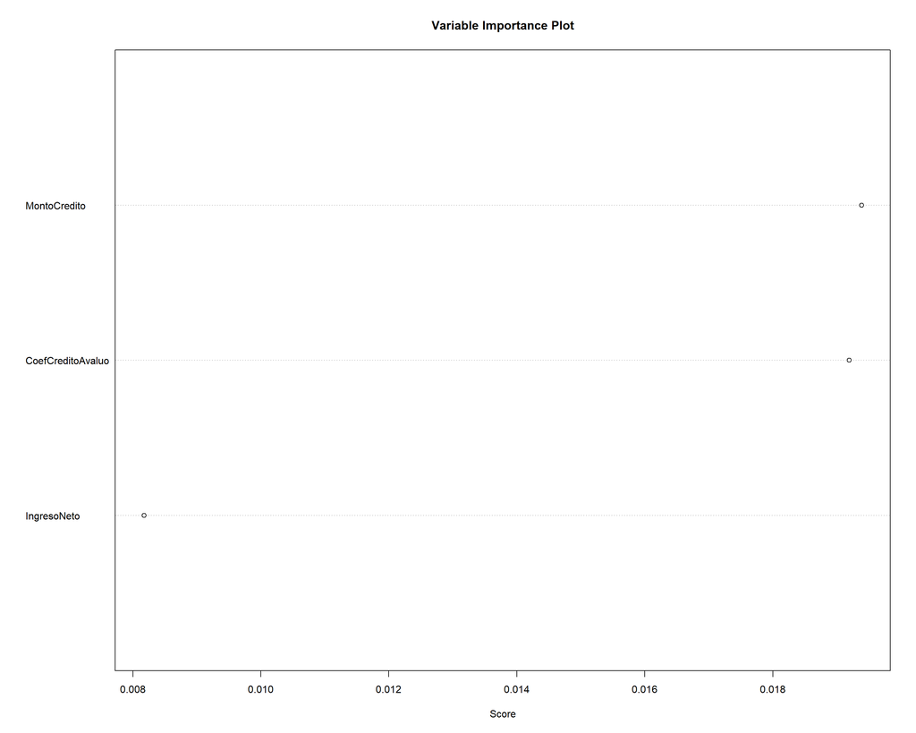

```r
varplot(modelo)
```

**Se genera la matriz de confusión**

```r
MC <- confusion.matrix(ttesting, prediccion)
MC
```

```
    prediction
real  No  Si
  No  23  87
  Si  14 626
```

**Índices de calidad de la predicción**

```r
indices <- general.indexes(mc = MC)
indices
```

```
Confusion Matrix:
    prediction
real  No  Si
  No  23  87
  Si  14 626

Overall Accuracy: 0.8653
Overall Error:    0.1347

Category Accuracy:

           No           Si
     0.209091     0.978125
```

**Podemos omitir crear la matriz de confusión**

```r
indices <- general.indexes(ttesting, prediccion)
indices
```

```
Confusion Matrix:
    prediction
real  No  Si
  No  23  87
  Si  14 626

Overall Accuracy: 0.8653
Overall Error:    0.1347

Category Accuracy:

           No           Si
     0.209091     0.978125
```